# 데이터 시각화

정적 시각화 효과 극대화

xwMOOC

Tidyverse Korea

2019-03-01

# 1 참된 데이터 시각화

## 1.1 데이터 시각화 비고 [^1]

동일한 데이터를 4가지 방식으로 시각화할 경우 추하고(ugly), 악의적으로 나쁘게(bad), 틀리게(wrong) 작성할 수도 있다.

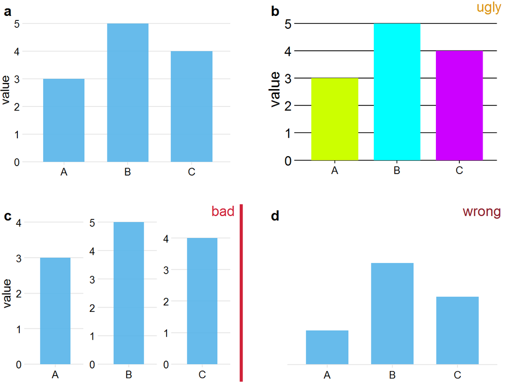

```r
devtools::install_github("clauswilke/dviz.supp")
library(dviz.supp)

df <- tibble(
  type = c("A", "B", "C"),
  value = c(3, 5, 4),
  expand = c(4, 5, 4.5)
)
p1 <- ggplot(df, aes(type, value)) +
  geom_col(fill = "#56B4E9", width = 0.65, alpha = 0.9) +
  scale_y_continuous(limits = c(0, 5.2), expand = c(0, 0)) +
  scale_x_discrete(name = NULL) +
  coord_cartesian(clip = "off") +
  theme_dviz_hgrid(12) +
  theme(
    axis.line = element_blank(),
    plot.margin = margin(18, 12, 0, 0)
  )
p2 <- ggplot(df, aes(type, value)) +
  geom_col(fill = c("#CCFF00FF", "#00FFFFFF", "#CC00FFFF"), width = 0.75) +
  scale_y_continuous(limits = c(0, 5.2), expand = c(0, 0)) +
  scale_x_discrete(name = NULL) +
  coord_cartesian(clip = "off") +
  theme_dviz_hgrid(12) +
  theme(
    axis.line = element_blank(),
    axis.title = element_text(family = "Comic Sans MS", size = 15),
    axis.text.x = element_text(family = "Times", size = 10),
    axis.text.y = element_text(family = "Arial", size = 13),
    panel.grid = element_line(color = "black"),
    axis.ticks = element_line(color = "black"),
    plot.margin = margin(18, 12, 1.5, 1.5)
  )
p3 <- ggplot(df, aes(type, value)) +
  geom_col(fill = "#56B4E9", width = 0.65, alpha = 0.9) +
  geom_point(aes(y = expand), shape = NA) +
  scale_y_continuous(expand = c(0, 0)) +
  scale_x_discrete(name = NULL) +
  facet_wrap(~type, scales = "free") +
  coord_cartesian(clip = "off") +
  theme_dviz_hgrid(12) +
  theme(
    axis.line = element_blank(),
    strip.text = element_blank(),
    plot.margin = margin(18, 12, 1.5, 1.5)
  )
p3a <- ggplot(df, aes(type, value)) +
  geom_col(color = "black", fill = NA, width = .5) +
  scale_y_continuous(limits = c(0, 5.2), expand = c(0, 0)) +
  scale_x_discrete(name = NULL) +
  coord_cartesian(clip = "off") +
  theme_dviz_grid(12) +
  background_grid(
    major = "y", minor = "none",
    colour.major = "grey30", colour.minor = "black",
    size.major = 0.5,
    size.minor = 0.2
  ) +
  theme(
    axis.ticks = element_line(color = "grey30"),
    plot.margin = margin(18, 12, 1.5, 1.5)
  )
p4 <- ggplot(df, aes(type, value)) +
  geom_col(fill = "#56B4E9", width = 0.65, alpha = 0.9) +
  coord_cartesian(xlim = c(0.4, 3.6), ylim = c(2, 6.2), expand = FALSE, clip = "on") +
  scale_y_continuous(breaks = 2:4, name = "", labels = c("", "", "")) +
  scale_x_discrete(name = NULL) +
  theme_dviz_hgrid(12) +
  theme(
    panel.grid.major.y = element_blank(),
    axis.ticks.y = element_blank(),
    plot.margin = margin(18, 12, 1.5, 1.5)
  )
cowplot::plot_grid(
  p1, NULL, stamp_ugly(p2),
  NULL, NULL, NULL,
  stamp_bad(p3), NULL, stamp_wrong(p4),
  rel_widths = c(1, .1, 1),
  rel_heights = c(1, .15, 1),
  labels = c("a", "", "b", "", "", "", "c", "", "d")
)
```

## 1.2 시계열 데이터 사례비교

시계열 데이터도 예외는 아니다. 시간의 흐름에 따라 최근 인기를 얻고 있는 `Preprints` 논문서비스 건수를 시각할 때 단순히 점을 찍게 되면 전반적인 추세를 파악할 수도 있으나, 그보다는 점을 선으로 연결시키고 각 논문 서비스마다 색상을 달리하게 되면 더 좋아지지만, 가장 나은 방법은 점을 없애고 각 논문 서비스마다 시계열 말미에 라벨을 붙이는 것이 시각적인 인지부하를 최소화하게 되는 시각화 산출물이 된다.

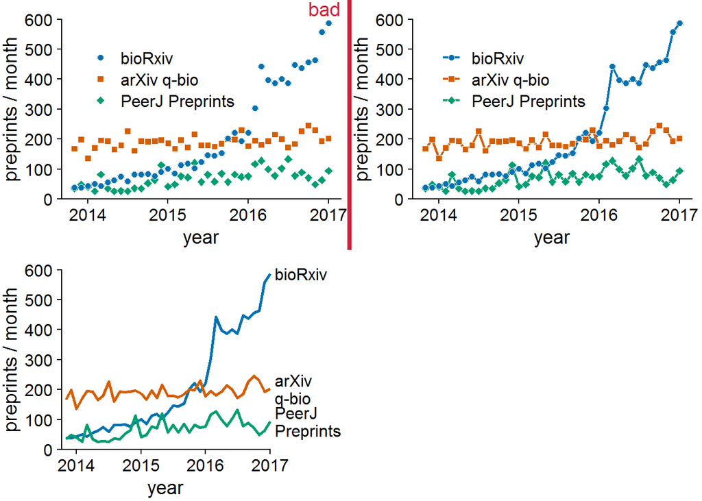

```r
library(lubridate)
biorxiv_growth <- preprint_growth %>% filter(archive == "bioRxiv") %>%
  filter(count > 0)

preprint_growth %>% filter(archive %in% c("bioRxiv", "arXiv q-bio", "PeerJ Preprints")) %>%
  filter(count > 0) %>%
  mutate(archive = factor(archive, levels = c("bioRxiv", "arXiv q-bio", "PeerJ Preprints")))-> preprints

preprint_g <- ggplot(preprints, aes(date, count, color = archive, fill = archive, shape = archive)) +
  geom_point(color = "white", size = 2) +
  scale_shape_manual(values = c(21, 22, 23),
                     name = NULL) +
  scale_y_continuous(limits = c(0, 600), expand = c(0, 0),
                name = "preprints / month") +
  scale_x_date(name = "year",
               limits = c(min(biorxiv_growth$date), ymd("2017-01-01"))) +
  scale_color_manual(values = c("#0072b2", "#D55E00", "#009e73"),
                     name = NULL) +
  scale_fill_manual(values = c("#0072b2", "#D55E00", "#009e73"),
                     name = NULL) +
  theme_dviz_open() +
  theme(legend.title.align = 0.5,
        legend.position = c(0.1, .9),
        legend.just = c(0, 1),
        plot.margin = margin(14, 7, 3, 1.5))

trendline_g <- ggplot(preprints, aes(date, count, color = archive, fill = archive, shape = archive)) +
  geom_line(size = 0.75) + geom_point(color = "white", size = 2) +
  scale_y_continuous(limits = c(0, 600), expand = c(0, 0),
                name = "preprints / month") +
  scale_x_date(name = "year",
               limits = c(min(biorxiv_growth$date), ymd("2017-01-01"))) +
  scale_color_manual(values = c("#0072b2", "#D55E00", "#009e73"),
                     name = NULL) +
  scale_fill_manual(values = c("#0072b2", "#D55E00", "#009e73"),
                     name = NULL) +
  scale_shape_manual(values = c(21, 22, 23),
                     name = NULL) +
  theme_dviz_open() +
  theme(legend.title.align = 0.5,
        legend.position = c(0.1, .9),
        legend.just = c(0, 1),
        plot.margin = margin(14, 7, 3, 1.5))

preprints_final <- filter(preprints, date == lubridate::ymd("2017-01-01"))

trendline_best_g <- ggplot(preprints) +
  aes(date, count, color = archive, fill = archive, shape = archive) +
  geom_line(size = 1) +
  #geom_point(color = "white", size = 2) +
  scale_y_continuous(
    limits = c(0, 600), expand = c(0, 0),
    name = "preprints / month",
    sec.axis = dup_axis(
      breaks = preprints_final$count,
      labels = c("arXiv\nq-bio", "PeerJ\nPreprints", "bioRxiv"),
      name = NULL)
  ) +
  scale_x_date(name = "year",
               limits = c(min(biorxiv_growth$date), ymd("2017-01-01")),
               expand = expand_scale(mult = c(0.02, 0))) +
  scale_color_manual(values = c("#0072b2", "#D55E00", "#009e73"),
                     name = NULL) +
  scale_fill_manual(values = c("#0072b2", "#D55E00", "#009e73"),
                     name = NULL) +
  scale_shape_manual(values = c(21, 22, 23),
                     name = NULL) +
  coord_cartesian(clip = "off") +
  theme_dviz_open() +
  theme(legend.position = "none") +
  theme(axis.line.y.right = element_blank(),
        axis.ticks.y.right = element_blank(),
        axis.text.y.right = element_text(margin = margin(0, 0, 0, 0)),
        plot.margin = margin(14, 7, 3, 1.5))

cowplot::plot_grid(stamp_bad(preprint_g), trendline_g, trendline_best_g, nrow=2)
```

## 1.3 데이터 픽셀 비율 [^2] [^3] [^4]

시각화의 중요한 원칙중의 하나는 화면 전체 픽셀(pixel)과 정보를 표현하는 픽셀 비율을 최대화하는 것이다. 흔히 데이터와 픽셀 비율(data to pixel ratio)로 계량화하는데 데이터-픽셀 비율이 낮는 경와 데이터-픽셀 비율이 높은 경우를 다음 사례를 통해 쉽게 파악할 수 있다.

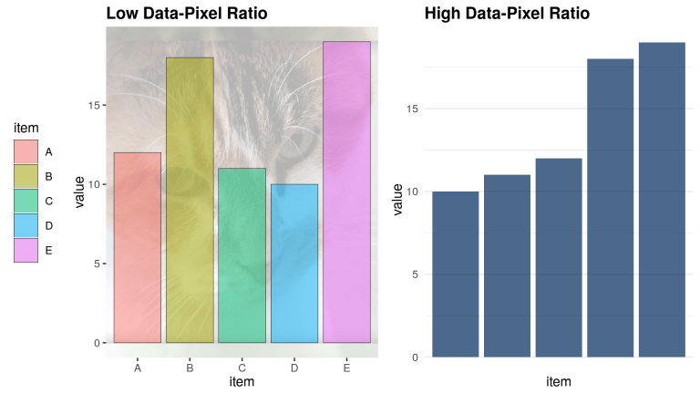

## 1.4 Aesthetics

시각화를 할 경우 위치(position), 모양(shape), 크기(size), 색상(color), 선굵기(line width), 선유형(line type)을 사용하여 좌표계(coordinate system), 척도(scale)와 결합하여 시각화 결과물을 제작한다.

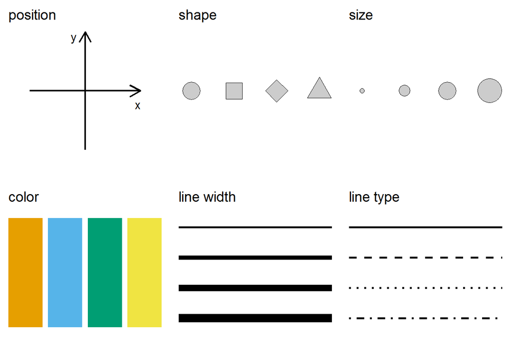

```r
aes_pos <- ggdraw() +
  geom_segment(data = data.frame(x = c(0, 0.5),
                                 xend = c(1, 0.5),
                                 y = c(0.5, 0),
                                 yend = c(0.5, 1)),
                aes(x = x, y = y, xend = xend, yend = yend),
                arrow = arrow(length = grid::unit(12, "pt")), size = .75) +
  draw_text("y", .5, 1, size = 12, vjust = 1, hjust = 2.5, family = dviz_font_family) +
  draw_text("x", 1, .5, size = 12, vjust = 2, hjust = 1, family = dviz_font_family) +
  coord_cartesian(xlim = c(-.2, 1.2), ylim = c(-.2, 1.2))

aes_color <- ggdraw() +
  geom_tile(data = data.frame(x = 0.15 + .2333*(0:3)),
            aes(x, y = .5, fill = factor(x)), width = .2, height = .6) +
  scale_fill_OkabeIto(guide = "none")

aes_shape <- ggdraw() +
  geom_point(data = data.frame(x = (.5 + 0:3)/4),
             aes(x, y = .5, shape = factor(x)), size = 8, fill = "grey80") +
  scale_shape_manual(values = 21:24)

aes_size <- ggdraw() +
  geom_point(data = data.frame(x = (.5 + 0:3)/4),
             aes(x, y = .5, size = factor(x)), shape = 21, fill = "grey80") +
  scale_size_manual(values = c(2, 5, 8, 11))

aes_lwd <- ggdraw() +
  geom_segment(data = data.frame(x = rep(0.05, 4),
                                 xend = rep(0.95, 4),
                                 y = (1.5 + 0:3)/6,
                                 yend = (1.5 + 0:3)/6,
                                 size = 4:1),
               aes(x = x, y = y, xend = xend, yend = yend, size = size)) +
  scale_size_identity()

aes_ltp <- ggdraw() +
  geom_segment(data = data.frame(x = rep(0.05, 4),
                                 xend = rep(0.95, 4),
                                 y = (1.5 + 0:3)/6,
                                 yend = (1.5 + 0:3)/6,
                                 linetype = 4:1),
               aes(x = x, y = y, xend = xend, yend = yend, linetype = linetype), size = 1) +
  scale_linetype_identity()

plot_grid(aes_pos, aes_shape, aes_size,
          aes_color, aes_lwd, aes_ltp,
          ncol = 3,
          labels = c("position", "shape", "size", "color", "line width", "line type"),
          label_x = 0.05, label_y = 0.95, hjust = 0, vjust = 1)
```

데이터값을 aesthetics에 매핑시켜려며, 데이터값이 aesthetics 특정값에 대응되는 것을 명세하여야 한다. `scales`를 통해서 데이터값과 aesthetics 값 사이의 매핑이 이뤄진다.

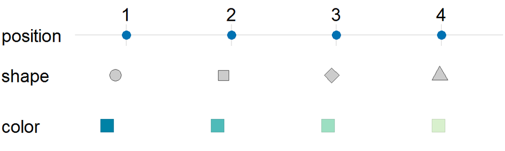

```r
df <- data.frame(x = c(1:4))

scale_num <- ggplot(df, aes(x)) +
  geom_point(size = 3, color = "#0072B2", y = 1) +
  scale_y_continuous(limits = c(0.8, 1.2), expand = c(0, 0), breaks = 1, label = "position  ") +
  scale_x_continuous(limits = c(.7, 4.4), breaks = 1:5, labels = c("1", "2", "3", "4", "5"), name = NULL, position = "top") +
  theme_dviz_grid() +
  theme(axis.ticks.length = grid::unit(0, "pt"),
        axis.text = element_text(size = 14),
        axis.title.y = element_blank(),
        axis.ticks.y = element_blank())
scale_color <- ggplot(df, aes(x, color = factor(x), fill = factor(x))) +
  geom_point(size = 5, shape = 22, y = 1) +
  scale_y_continuous(limits = c(0.8, 1.2), expand = c(0, 0), breaks = 1, label = "color  ") +
  scale_x_continuous(limits = c(.7, 4.4), breaks = NULL) +
  scale_color_manual(values = darken(c("#0082A6", "#4EBBB9", "#9CDFC2", "#D8F0CD"), .1), guide = "none") +
  scale_fill_manual(values = c("#0082A6", "#4EBBB9", "#9CDFC2", "#D8F0CD"), guide = "none") +
  theme_dviz_grid() +
  theme(axis.ticks.length = grid::unit(0, "pt"),
        axis.text.x = element_blank(),
        axis.text.y = element_text(size = 14),
        axis.title = element_blank(),
        axis.ticks = element_blank(),
        panel.grid.major = element_blank())

scale_shape <- ggplot(df, aes(x, shape = factor(x))) +
  geom_point(size = 4, color = "grey30", y = 1, fill = "grey80") +
  scale_y_continuous(limits = c(0.8, 1.2), expand = c(0, 0), breaks = 1, label = "shape  ") +
  scale_x_continuous(limits = c(.7, 4.4), breaks = NULL) +
  scale_shape_manual(values = 21:24, guide = "none") +
  theme_dviz_grid() +
  theme(axis.ticks.length = grid::unit(0, "pt"),
        axis.text.x = element_blank(),
        axis.text.y = element_text(size = 14),
        axis.title = element_blank(),
        axis.ticks = element_blank(),
        panel.grid.major = element_blank())

cowplot::plot_grid(scale_num, scale_shape, scale_color, ncol = 1)
```

# 2 강조(하이라이트) [^5]

[`gghighlight`](https://github.com/yutannihilation/gghighlight) 팩키지를 통해 직접 특정부분을 강조하는 시각화 산출물을 작성해도 좋지만, [“Anatomy of gghighlight”](https://yutani.rbind.io/post/2018-06-03-anatomy-of-gghighlight/) 블로그 내용을 바탕으로 강조(하이라이트)하는 원칙을 살펴보자.

## 2.1 강조(하이라이트) 원리 [^6]

붓꽃 `iris` 데이터를 배경을 깔고 종별로 히스토그램을 비교하는 시각화 산출물을 작성해 보자.

이를 위해서 먼저 `iris_bg` 데이터프레임을 하나 제작하고 `Sepal.Width` 변수로 히스토그램을 작성한다. `iris_bg` 배경 데이터프레임으로 히스토그램을 만들고 `facet_warp()` 함수로 종별로 히스토그램을 완성시킨다. 원리는 `geom_histogram()` 첫번째 히스토그램은 `iris_bg` 데이터프레임을 활용하여 종족이 없는 `Sepal.Width` 전체 종에 대한 히스토그램을 만들고, 두번째 히스토그램은 디폴트 설정된 색이 반영된 `iris` 데이터프레임에 대한 색상을 얻게된 히스토그램이 제작된다. 마지막으로 `facet_wrap()`으로 붓꽃 종별로 히스토그램이 나뉘어서 시각화된다.

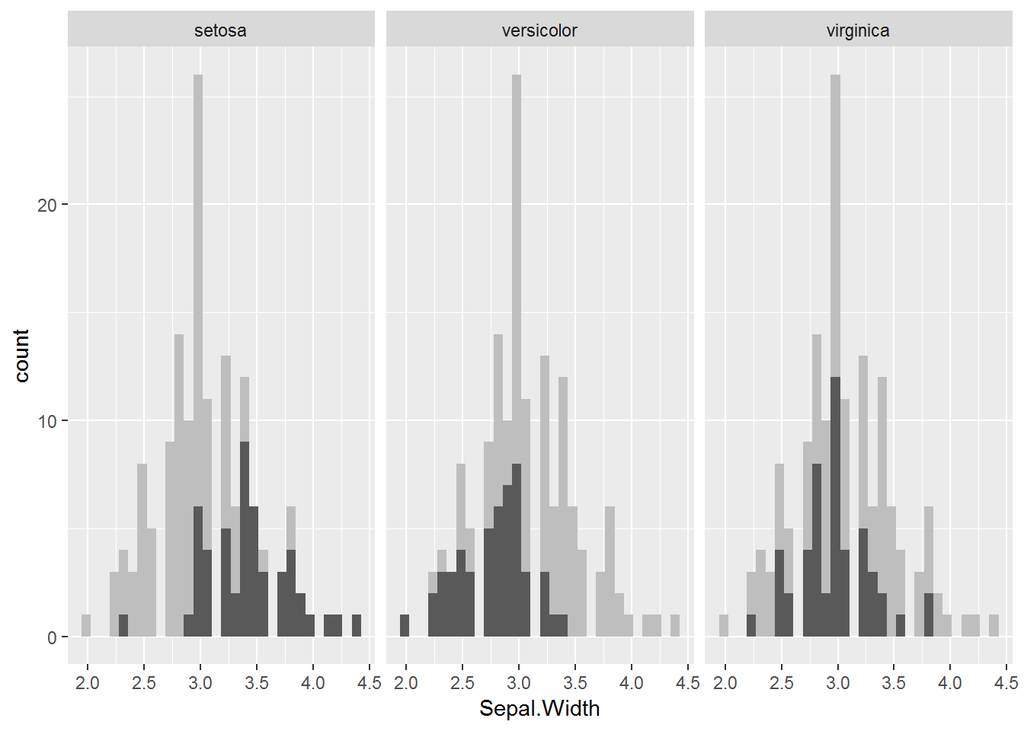

```r
library(tidyverse)

iris_bg <- iris[, -5]  # Background Data - full without the 5th column (Species)

ggplot(iris, aes(x = Sepal.Width)) +
  geom_histogram(data = iris_bg, fill = "grey") +
  geom_histogram() +
  facet_wrap(~ Species)
```

색상도 각 붓꽃 종별로 넣고 보기좋게 작업한 코드는 다음과 같다.

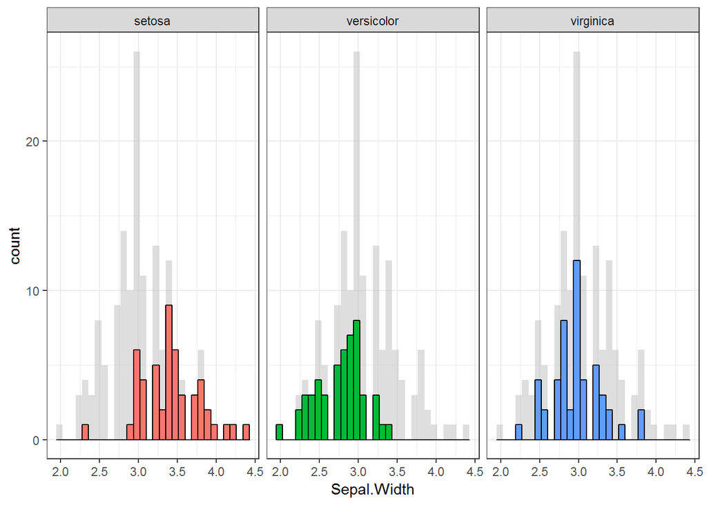

```r
ggplot(iris, aes(x = Sepal.Width, fill = Species)) +
  geom_histogram(data = iris_bg, fill = "grey", alpha = .5) +
  geom_histogram(colour = "black") +
  facet_wrap(~ Species) +
  guides(fill = FALSE) +  # to remove the legend
  theme_bw()              # for clean look overall
```

`gghighlight` 팩키지를 활용하여 붓꽃 종별로 강조 하이라이트를 수월히 할 수 있다.

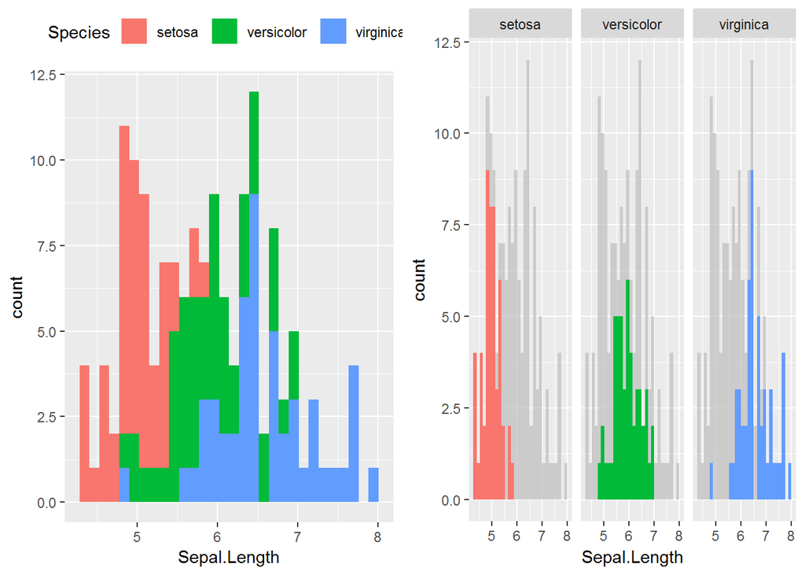

```r
library(gghighlight)

species_g <- ggplot(iris, aes(Sepal.Length, fill = Species)) +
  geom_histogram() +
  theme(legend.position = "top")

species_highlight_g <- ggplot(iris, aes(Sepal.Length, fill = Species)) +
  geom_histogram() +
  gghighlight() +
  facet_wrap(~ Species)

cowplot::plot_grid(species_g, species_highlight_g)
```

# 3 강조(하이라이트) 사례

## 3.1 막대그래프 강조(하이라이트)

### 3.1.1 막대그래프 색상

`geom_bar()` 함수에 `fill=` 인자를 `if_else()`와 결합하여 색상을 달리 차별화 시킨다.

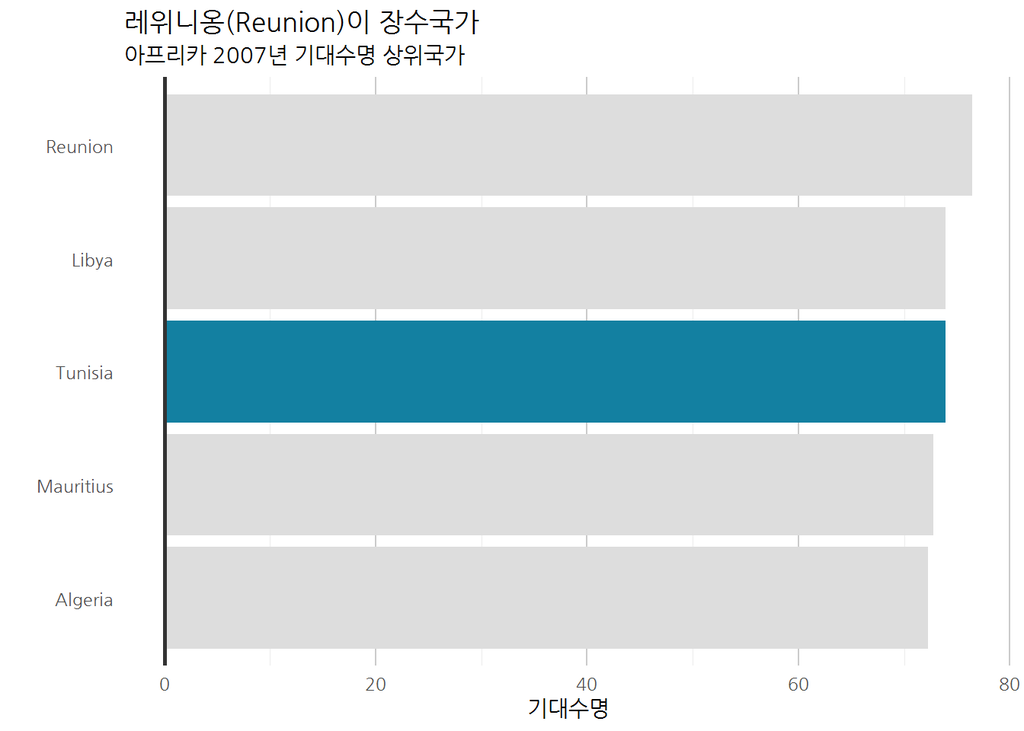

```r
library(bbplot)
library(tidyverse)
library(gapminder)
library(extrafont)
loadfonts()

top_five_df <- gapminder %>%
  filter(year == 2007 & continent == "Africa") %>%
  top_n(5, wt=lifeExp)

top_five_df %>%
  ggplot(aes(x = fct_reorder(country, lifeExp), y = lifeExp)) +
  geom_bar(stat="identity", position="identity",
           fill=if_else(top_five_df$country == "Tunisia", "#1380A1", "#dddddd")) +
  geom_hline(yintercept = 0, size = 1, colour="#333333") +
  theme_minimal(base_family="NanumGothic") +
  coord_flip() +
  labs(title="레위니옹(Reunion)이 장수국가",
       subtitle = "아프리카 2007년 기대수명 상위국가") +
  theme(panel.grid.major.x = element_line(color="#cbcbcb"),
        panel.grid.major.y=element_blank()) +
  labs(x="", y="기대수명")
```

### 3.1.2 막대그래프 + 라벨

`geom_label()` 함수에 `aes()` 함수 내부에 `label=` 인자를 넣어 라벨을 붙일 수 있고, 라벨 색상을 `color=` 인자에 `if_else()`를 조합시켜 강조하여 가시성을 높인다.

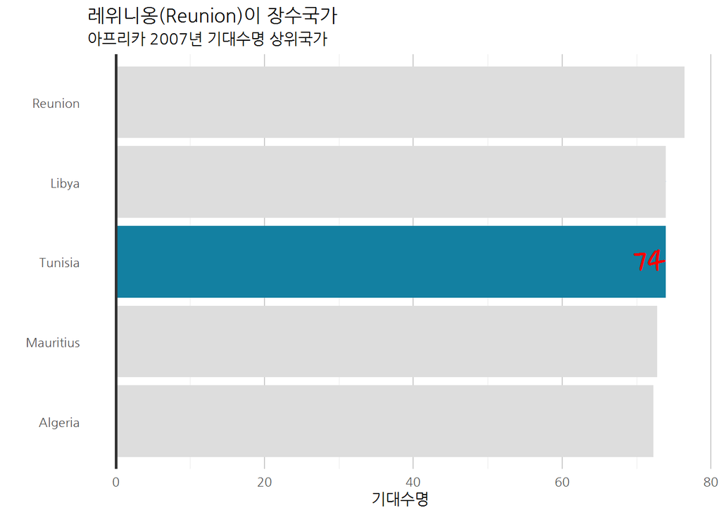

```r
top_five_df <- gapminder %>%
  filter(year == 2007 & continent == "Africa") %>%
  top_n(5, wt=lifeExp)

top_five_df %>%
  ggplot(aes(x = fct_reorder(country, lifeExp), y = lifeExp)) +
  geom_bar(stat="identity", position="identity",
           fill=if_else(top_five_df$country == "Tunisia", "#1380A1", "#dddddd")) +
  geom_hline(yintercept = 0, size = 1, colour="#333333") +
  theme_minimal(base_family="NanumGothic") +
  coord_flip() +
  labs(title="레위니옹(Reunion)이 장수국가",
       subtitle = "아프리카 2007년 기대수명 상위국가") +
  theme(panel.grid.major.x = element_line(color="#cbcbcb"),
        panel.grid.major.y=element_blank()) +
  labs(x="", y="기대수명") +
  geom_label(aes(x = country,
                 y = lifeExp - 6,
                 label = round(lifeExp, 0)),
             hjust = 0,
             vjust = 0.5,
             colour = if_else(top_five_df$country == "Tunisia", "red", "#dddddd"),
             fill = NA,
             label.size = NA,
             family="Nanum Pen Script",
             size = 10)
```

## 3.2 선그래프 강조(하이라이트)

### 3.2.1 선그래프 색상

`geom_line()` 선그래프 색상을 `scale_colour_manual()` 함수에 `value=` 인자를 달리하여 차별화할 수 있다.

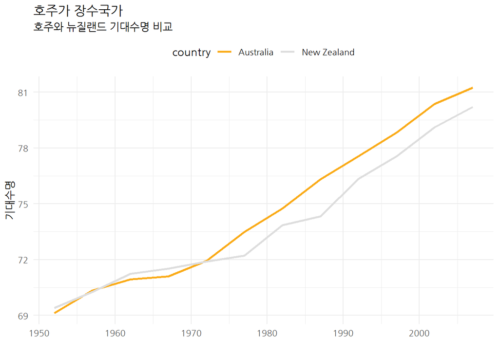

```r
oceania_df <- gapminder %>%
  filter(continent == "Oceania")

oceania_df %>%
  ggplot(aes(x = year, y = lifeExp, colour = country)) +
    geom_line(size = 1) +
    scale_colour_manual(values = c("#FAAB18", "#dddddd")) +
    theme_minimal(base_family = "NanumGothic") +
    labs(title="호주가 장수국가",
         subtitle = "호주와 뉴질랜드 기대수명 비교") +
    theme(legend.position = "top") +
    labs(x="", y="기대수명")
```

### 3.2.2 선그래프 색상 + 라벨

또한, `geom_label()`과 `geom_curve()`를 사용하여 특정 지점에 화살표를 넣어 라벨을 붙여 강조하는 것도 가능하다.

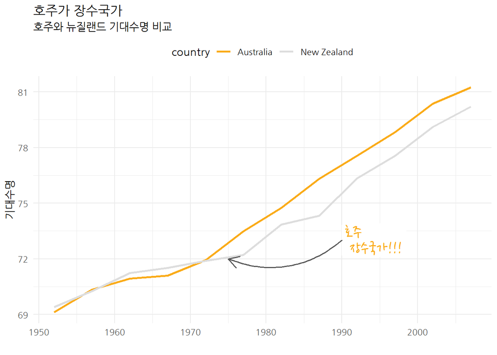

```r
oceania_df <- gapminder %>%
  filter(continent == "Oceania")

oceania_df %>%
  ggplot(aes(x = year, y = lifeExp, colour = country)) +
    geom_line(size = 1) +
    scale_colour_manual(values = c("#FAAB18", "#dddddd")) +
    theme_minimal(base_family = "NanumGothic") +
    labs(title="호주가 장수국가",
         subtitle = "호주와 뉴질랜드 기대수명 비교") +
    theme(legend.position = "top") +
    labs(x="", y="기대수명") +
    geom_label(aes(x = 1990, y = 73, label = "호주 \n 장수국가!!!"),
             hjust = 0,
             vjust = 0.5,
             lineheight = 0.8,
             colour = "#FAAB18",
             fill = "white",
             label.size = NA,
             family="Nanum Pen Script",
             size = 6) +
     geom_curve(aes(x = 1990, y = 73, xend = 1975, yend = 72),
                   colour = "#555555",
                   curvature = -0.3,
                   size=0.7,
                   arrow = arrow(length = unit(0.05, "npc")))
```

## 3.3 히스토그램 강조(하이라이트) [^7]

### 3.3.1 단변량 히스토그램

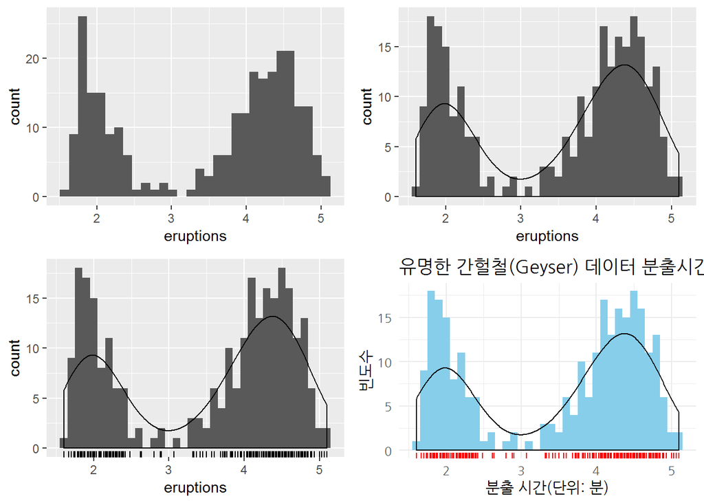

```r
orig_hist_g <- faithful %>%
  ggplot(aes(x=eruptions)) +
    geom_histogram()

density_hist_g <- faithful %>%
  ggplot(aes(x=eruptions)) +
    geom_histogram(binwidth = 0.1) +
    geom_density(aes(y=..count.. * 0.1 ))

rug_hist_g <- faithful %>%
  ggplot(aes(x=eruptions)) +
    geom_histogram(binwidth = 0.1) +
    geom_density(aes(y= 0.1 * ..count..)) +
    geom_rug()

deco_hist_g <- faithful %>%
  ggplot(aes(x=eruptions)) +
    geom_histogram(binwidth = 0.1, fill="skyblue") +
    geom_density(aes(y=0.1 * ..count..)) +
    geom_rug(colour="red") +
    labs(x="분출 시간(단위: 분)", y="빈도수",
         title="유명한 간헐철(Geyser) 데이터 분출시간") +
    theme_minimal(base_family = "NanumGothic")

cowplot::plot_grid(orig_hist_g, density_hist_g, rug_hist_g, deco_hist_g)
```

### 3.3.2 집단 비교

집단간 분포 비교를 위해서 종전 히스토그램과 밀도그래프(density plot)외에 최근에 바이올린(violin) 그래프와 능선(ridge) 그래프도 많이 사용되고 있다.

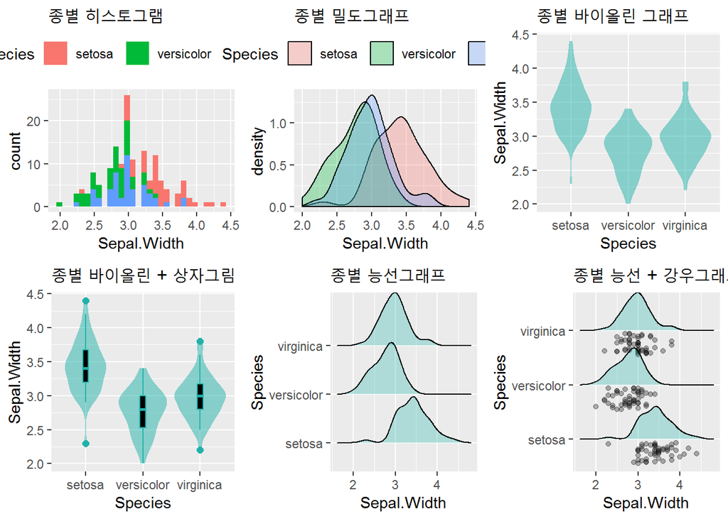

```r
library(ggridges)

iris_df <- iris %>% tbl_df()

hist_group_g <- iris_df %>%
  ggplot(aes(x=Sepal.Width, fill=Species)) +
    geom_histogram()  +
    labs(title="종별 히스토그램") +
    theme(legend.position = "top")

density_group_g <- iris_df %>%
  ggplot(aes(x=Sepal.Width, fill=Species)) +
    geom_density(alpha=0.3) +
    labs(title="종별 밀도그래프") +
    theme(legend.position = "top")

boxplot_group_g <- iris_df %>%
  ggplot(aes(y=Sepal.Width, fill=Species)) +
    geom_boxplot(alpha=0.3)   +
    labs(title="종별 상자그림")

violin_group_g <- iris_df %>%
  ggplot(aes(y=Sepal.Width, x=Species)) +
    geom_violin(color = NA,
                fill = "lightseagreen",
                alpha = .5,
                na.rm = TRUE,
                scale = "count") +
    labs(title="종별 바이올린 그래프")

violin_boxplot_group_g <- iris_df %>%
  ggplot(aes(y=Sepal.Width, x=Species)) +
    geom_violin(color = NA,
                fill = "lightseagreen",
                alpha = .5,
                na.rm = TRUE,
                scale = "count") +
    geom_boxplot(outlier.size = 2,
                 colour = "lightseagreen",
                 fill = "black",
                 na.rm = TRUE,
                 width = .1) +
    labs(title="종별 바이올린 + 상자그림")


ridge_group_g <- iris_df %>%
  ggplot(aes(x=`Sepal.Width`, y=Species)) +
    geom_density_ridges(scale = 1.1,
                        fill = "lightseagreen",
                        alpha=0.3)   +
    labs(title="종별 능선그래프")

raincloud_group_g <- iris_df %>%
  ggplot(aes(x=`Sepal.Width`, y=Species)) +
    geom_density_ridges(jittered_points = TRUE,
                        position = "raincloud",
                        scale = 0.7,
                        fill = "lightseagreen",
                        alpha=0.3)    +
    labs(title="종별 능선 + 강우그래프")

cowplot::plot_grid(hist_group_g, density_group_g,
                   violin_group_g, violin_boxplot_group_g,
                   ridge_group_g, raincloud_group_g)
```

### 3.3.3 집단 비교 - 벌꿀무리

과거 `stripchart`를 사용해서 각 개별 관측점을 집단별로 비교하는 시각화를 많이 사용했는데 최근 `geom_beeswarm()`을 사용해서 이를 대체하고 있다.

1. `geom_jitter()` + `stat_summary()`을 조합시키면 `stripchart` 기능을 `ggplot`에서 구현시킬 수 있다.
2. 점그림(`dotplot`)은 `beeswarm` 그래프와 동일하지는 않지만 유사한 기능을 구현할 수 있다.
3. [`ggbeeswarm`](https://github.com/eclarke/ggbeeswarm)은 관측점을 점으로 찍어 직관적으로 집단간 비교도 수월하게 시각적한다.

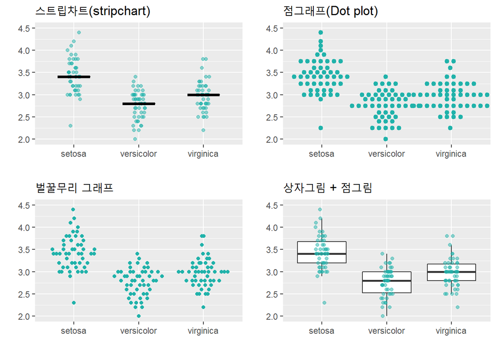

```r
library(ggbeeswarm)

# Stripchart
strip_g <- iris_df %>%
  ggplot(aes(x = Species, y = Sepal.Width)) +
  geom_jitter(position = position_jitter(height = 0, width = .1),
              fill = "lightseagreen",
              colour = "lightseagreen",
              alpha = .5) +
  stat_summary(fun.y = median,
               fun.ymin = median,
               fun.ymax = median,
               geom = "crossbar",
               width = 0.5) +
  coord_cartesian(ylim = c(2, 4.5)) +
  labs(x="", y="", title="스트립차트(stripchart)")

# dotplot
dotplot_g <- iris_df %>%
  ggplot(aes(x = Species, y = Sepal.Width)) +
    geom_dotplot(stackdir = "center",
                 binaxis = "y",
                 binwidth = .1,
                 binpositions = "all",
                 stackratio = 1.5,
                 fill = "lightseagreen",
                 colour = "lightseagreen") +
    coord_cartesian(ylim = c(2, 4.5)) +
    labs(x="", y="", title="점그래프(Dot plot)")

# beeswarm
beeswarm_g <- iris_df %>%
  ggplot(aes(x = Species, y = Sepal.Width)) +
    geom_quasirandom(fill = "lightseagreen",
                     colour = "lightseagreen") +
    coord_cartesian(ylim = c(2, 4.5)) +
    labs(x="", y="", title="벌꿀무리 그래프")

# 상자그림 + 점그림
boxplot_dotplot_g <- iris_df %>%
  ggplot(aes(x = Species, y = Sepal.Width)) +
    geom_boxplot(outlier.shape = NA) +
    geom_jitter(fill = "lightseagreen",
                colour = "lightseagreen",
                na.rm = TRUE,
                position = position_jitter(height = 0, width = .1),
                alpha = .5) +
    coord_cartesian(ylim = c(2, 4.5)) +
    labs(x="", y="", title="상자그림 + 점그림")

cowplot::plot_grid(strip_g, dotplot_g,
                   beeswarm_g, boxplot_dotplot_g)
```

# 4 자주 사용되는 시각화

## 4.1 라벨 붙은 시계열

시계열 데이터에 마지막에 라벨을 붙이게 되면 가시성이 좋아진다. BLOGR 님이 작성한 [Label line ends in time series with ggplot2](https://drsimonj.svbtle.com/label-line-ends-in-time-series-with-ggplot2) 코드를 참조하여 `ggplot`으로 코드를 작성한다.

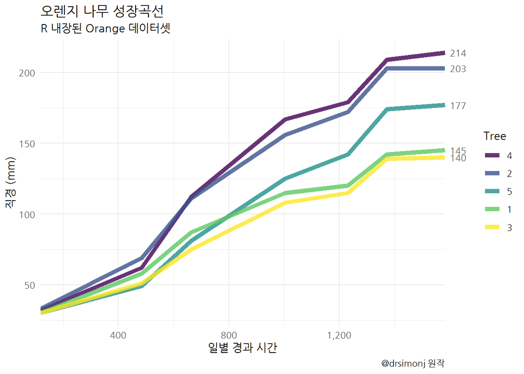

```r
orange_ends <- Orange %>%
  group_by(Tree) %>%
  top_n(1, age) %>%
  pull(circumference)

Orange %>%
  mutate(Tree = factor(Tree, levels=c(4,2,5,1,3))) %>%
  ggplot(aes(age, circumference, color = Tree)) +
    geom_line(size = 2, alpha = .8) +
    theme_minimal(base_family = "NanumGothic") +
    scale_x_continuous(expand = c(0, 0), label=scales::comma) +
    scale_y_continuous(sec.axis = sec_axis(~ ., breaks = orange_ends)) +
    labs(title = "오렌지 나무 성장곡선",
        subtitle = "R 내장된 Orange 데이터셋",
         x = "일별 경과 시간", y = "직경 (mm)",
         caption = "@drsimonj 원작")
```

## 4.2 막대그래프 그룹별 색상

TV 시리즈별 색상을 달리할 경우 `RColorBrewer` 팩키지 생상 팔레트를 범주형에 맞춰 각 시리즈별로 가장 잘 구분될 수 있도록 색상을 칠해 시각화를 한다.

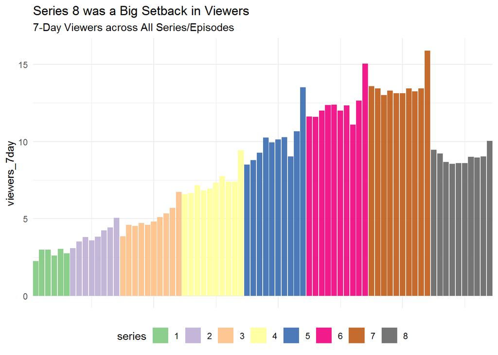

```r
ratings <- read_csv("http://bit.ly/cs631-ratings",
                    na = c("", "NA", "N/A"))

# 데이터 준비
ratings_bonanza1 <- ratings %>%
  mutate(ep_id = row_number(),
         series = as.factor(series)) %>%
  select(ep_id, viewers_7day, series)

# 시각화
barplot_pal <- RColorBrewer::brewer.pal(n=8, name = "Accent")

ggplot(ratings_bonanza1, aes(x = ep_id, y = viewers_7day,
                             fill = series)) +
  geom_col(alpha = .9) +
  theme_minimal() +
  ggtitle("Series 8 was a Big Setback in Viewers",
          subtitle= "7-Day Viewers across All Series/Episodes") +
  theme(legend.position = "bottom",
        text = element_text(family = "Lato"),
        axis.text.x = element_blank(),
        axis.ticks.x = element_blank(),
        axis.title.x = element_blank()) +
  scale_fill_manual(values = barplot_pal) +
  scale_x_continuous(expand = c(0, 0)) +
  guides(fill = guide_legend(nrow = 1))
```

## 4.3 롤리팝(lolli-pop) 그래프 [^8]

롤리팝(Lollipop) 그래프는 막대그래프와 클리블랜드 점그래프를 합성한 것으로 한축에는 연속형, 다른 한축에는 범주형을 두고 사용자의 관심을 점그래프로 집중시키는데 효과적이다.

막대그래프 → 점그래프 → 롤리팝 그래프로 뼈대 골격을 만들어 나간다.

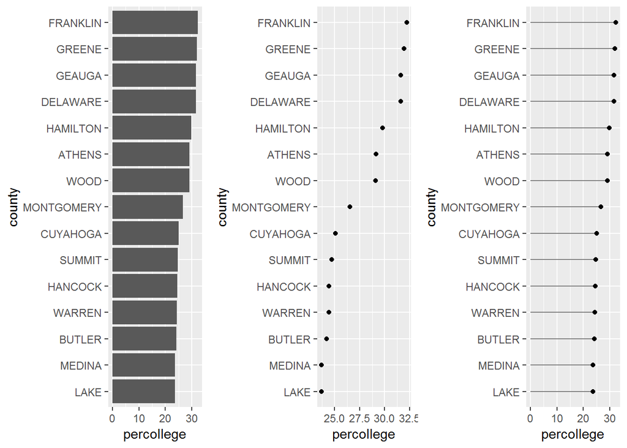

```r
# 데이터 -----
ohio_top15 <- midwest %>%
        filter(state == "OH") %>%
        select(county, percollege) %>%
        top_n(15, wt=percollege) %>%
        arrange(percollege) %>%
        mutate(county = factor(county, levels = .$county))

ohio_barplot_g <- ggplot(ohio_top15, aes(county, percollege)) +
        geom_col() +
        coord_flip()

ohio_dotplot_g <- ggplot(ohio_top15, aes(county, percollege)) +
        geom_point() +
        coord_flip()

ohio_lollipop_g <- ggplot(ohio_top15, aes(percollege, county)) +
        geom_segment(aes(x = 0, y = county,
                         xend = percollege, yend = county), color = "grey50") +
        geom_point()

cowplot::plot_grid(ohio_barplot_g, ohio_dotplot_g, ohio_lollipop_g, nrow=1)
```

평균값에서 얼마나 차이가 있느냐를 롤리팝 그래프로 시각화하는 패턴이 많이 사용된다. 이를 위해서, 앞서와 마찬가지로 사우이 15개 카운티를 뽑아내고 평균을 구하고 평균이상, 평균이하에 대한 요인(factor)도 함께 만들어낸다.

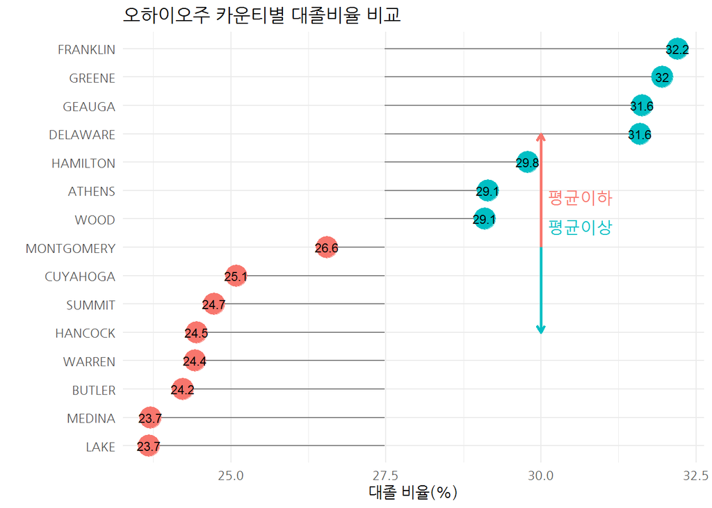

```r
ohio <- midwest %>%
        filter(state == "OH") %>%
        select(county, percollege) %>%
        top_n(15, wt=percollege) %>%
        arrange(percollege) %>%
        mutate(Avg = mean(percollege, na.rm = TRUE),
               Above = ifelse(percollege - Avg > 0, TRUE, FALSE),
               county = factor(county, levels = .$county))

comparison_lollipop_g <- ggplot(ohio, aes(percollege, county, color = Above)) +
        geom_segment(aes(x = Avg, y = county,
                         xend = percollege, yend = county), color = "grey50") +
        geom_point()

ggplot(ohio, aes(percollege, county, color = Above, label=round(percollege,1))) +
        geom_segment(aes(x = Avg, y = county,
                         xend = percollege, yend = county), color = "grey50") +
        geom_point(size=7) +
        annotate("text", x = 30, y = "WOOD", label = "평균이상", color = "#00BFC4", size = 5, hjust = -0.1, vjust = 1) +
        annotate("text", x = 30, y = "WOOD", label = "평균이하", color = "#F8766D", size = 5, hjust = -0.1, vjust = -1) +
        geom_text(color="black", size=3) +
        theme_minimal(base_family = "NanumGothic") +
        labs(x="대졸 비율(%)", y="",
             title="오하이오주 카운티별 대졸비율 비교")  +
        geom_segment(aes(x = 30, xend = 30 , y = "WOOD", yend = "HANCOCK"), size=1,
                     arrow = arrow(length = unit(0.2,"cm")), color = "#00BFC4") +
        geom_segment(aes(x = 30, xend = 30 , y = "MONTGOMERY", yend = "DELAWARE"), size=1,
                     arrow = arrow(length = unit(0.2,"cm")), color = "#F8766D") +
        theme(legend.position = "none")
```

## 4.4 추세선 강조 + 라벨

`geom_line()`을 두개 포함시켜 강조하고하는 색상을 별도로 지정하고 선굵기도 달리한다. 라벨도 동일한 방법으로 `geom_text()`를 두개 포함시켜 강조하고자하는 색상과 글꼴크기도 달리 지정한다.

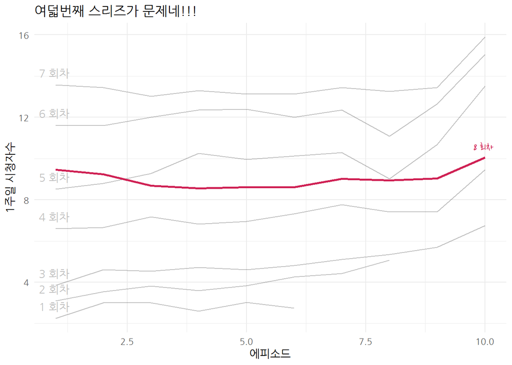

```r
ratings %>%
  mutate(episode = as.factor(episode)) %>%
  ggplot(aes(x = episode, y = viewers_7day, group = series)) +
    geom_line(data = filter(ratings, !series == 8), alpha = .25) +
    geom_line(data = filter(ratings, series == 8), color = "#CF2154", size=1) +
    theme_minimal(base_family = "NanumGothic") +
    labs(x = "에피소드", y="1주일 시청자수", title="여덟번째 스리즈가 문제네!!!") +
    geom_text(data = filter(ratings, episode == 1 & series %in% c(1:7)), color = "gray",
              aes(label = paste0(series, " 회차 ")), vjust = -1, family = "NanumGothic") +
    geom_text(data = filter(ratings, episode == 10 & series == 8), color = "#CF2154",
              aes(label = paste0(series, " 회차 ")), vjust = -1, family = "Nanum Pen Script")
```

## 4.5 아령(dumbbell) 그래프

TV 시리즈별로 회차를 달리하여 첫번째와 가장 마지막 시청자수를 비교하여 시각화하는데 아령(dumbbell) 그래프가 효과적이다. 이를 위해서 `ggplot()`에 들어가는 자료형을 미리 준비하고 이에 맞춰 `geom_line()`과 `geom_point()`를 결합시켜 시각화한다.

```r
ratings_dumbbell_df <- ratings %>%
  select(series, episode, viewers_7day) %>%
  group_by(series) %>%
  filter(episode == 1 | episode == max(episode)) %>%
  mutate(episode = ifelse(episode == 1,"1회차", "최종회")) %>%
  ungroup() %>%
  mutate(series = as.factor(series))

ratings_dumbbell_df
```

```
# A tibble: 16 x 3
   series episode viewers_7day
   <fct>  <chr>          <dbl>
 1 1      1회차           2.24
 2 1      최종회          2.75
 3 2      1회차           3.1
 4 2      최종회          5.06
 5 3      1회차           3.85
 6 3      최종회          6.74
 7 4      1회차           6.6
 8 4      최종회          9.45
 9 5      1회차           8.51
10 5      최종회         13.5
11 6      1회차          11.6
12 6      최종회         15.0
13 7      1회차          13.6
14 7      최종회         15.9
15 8      1회차           9.46
16 8      최종회         10.0
```

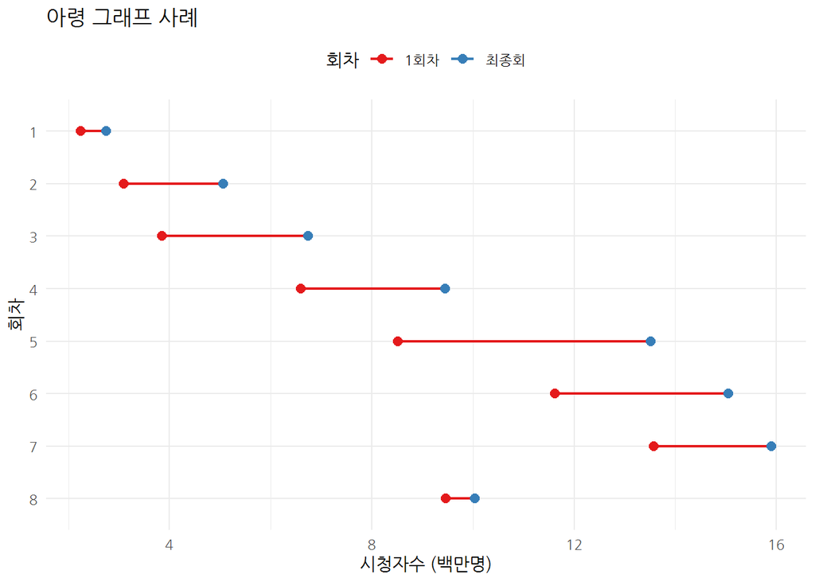

```r
# RColorBrewer::display.brewer.all()
dumbbell_pal <- RColorBrewer::brewer.pal(n=3, name="Set1")

ratings_dumbbell_df %>%
  ggplot(aes(x = viewers_7day, y = fct_rev(series), color = episode, group = series)) +
    geom_line(size = .75) +
    geom_point(size = 2.5) +
    theme_minimal() +
    scale_color_manual(values = dumbbell_pal) +
    labs(title = "아령 그래프 사례", y = "회차", x = "시청자수 (백만명)",
         color = "회차") +
    theme(text = element_text(family = "NanumGothic"),
          legend.position = "top")
```

## 4.6 경사(Slope) 그래프 [^9]

[`터프티(tufte)` 스타일 경사그래프](https://www.edwardtufte.com/bboard/q-and-a-fetch-msg?msg_id=0003nk)를 `ggplot`과 `dplyr`을 조합시켜 구현한다. 이를 위해서 먼저 `ggplot`의 기본기능을 활용하여 경사그래프를 시각화한다.

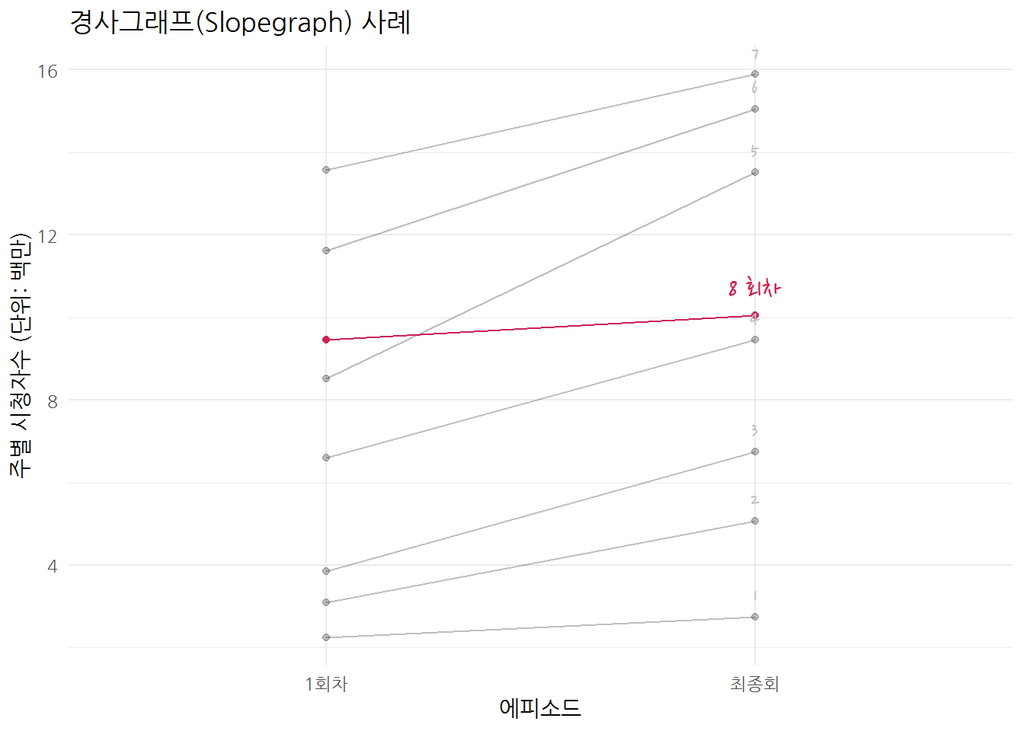

```r
ratings_dumbbell_df %>%
  ggplot(aes(x = episode, y = viewers_7day, group = series)) +
    geom_point(data = filter(ratings_dumbbell_df, !series == 8), alpha = .25) +
    geom_point(data = filter(ratings_dumbbell_df, series == 8), color = "#CF2154") +
    geom_line(data = filter(ratings_dumbbell_df, !series == 8), alpha = .25) +
    geom_line(data = filter(ratings_dumbbell_df, series == 8),color = "#CF2154") +
    theme_minimal(base_family = "NanumGothic") +
    labs(title = "경사그래프(Slopegraph) 사례", x="에피소드", y="주별 시청자수 (단위: 백만)") +
    geom_text(data = filter(ratings_dumbbell_df, episode == "최종회" & series %in% c(1:7)), color = "gray",
              aes(label = series), vjust = -1, family = "Nanum Pen Script", hjust = .5) +
    geom_text(data = filter(ratings_dumbbell_df, episode == "최종회" & series == 8), color = "#CF2154",
              aes(label = paste0(series, " 회차")), vjust = -1, family = "Nanum Pen Script", size=5)
```

[`slopegraph`](https://github.com/leeper/slopegraph) 팩키지로 대동단결하는 분위기다. 이를 바탕으로 경사그래프를 시각해보자.

```r
# devtools::install_github("leeper/slopegraph")
library(slopegraph)

data(cancer)
cancer %>% head
```

```
          Year.5 Year.10 Year.15 Year.20
Prostate      99      95      87      81
Thyroid       96      96      94      95
Testis        95      94      91      88
Melanomas     89      87      84      83
Breast        86      78      71      75
Hodgkin's     85      80      74      67
```

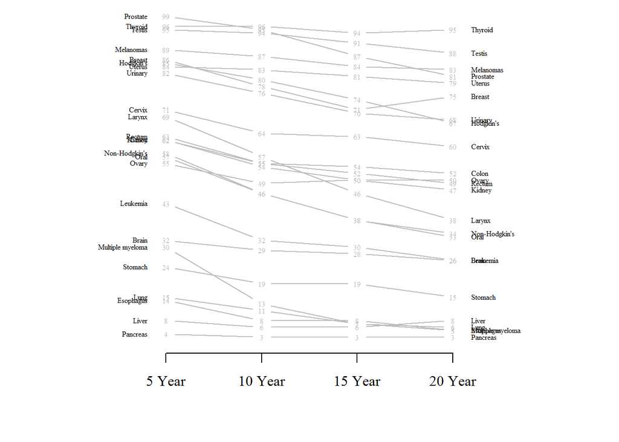

```r
slopegraph(cancer, col.lines = 'gray', col.lab = "black",
           xlim = c(-.5, 5.5), cex.lab = 0.5, cex.num = 0.5,
           xlabels = c('5 Year','10 Year','15 Year','20 Year'))
```

`slopegraph`는 Base 그래픽을 기본으로 제공한다. 자료구조도 `rownames`를 갖는 전통적인 데이터프레임이다. 기본 Base 그래픽을 염두에 두고 상기 TV 연속물 경사그래프를 다음과 같이 작성할 수 있다.

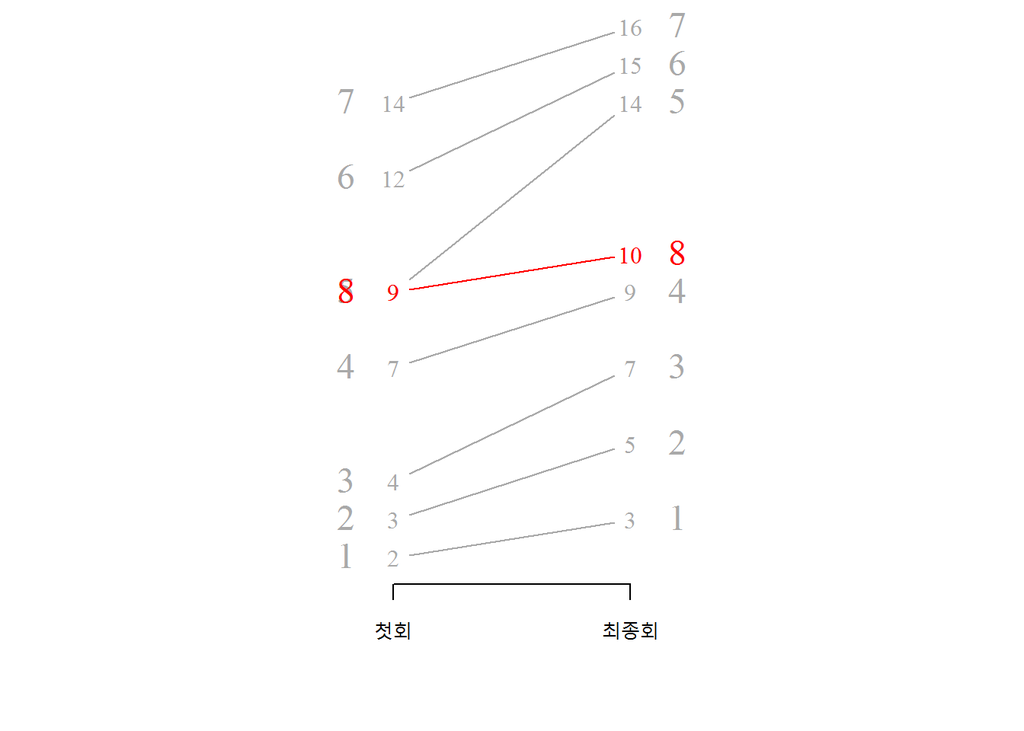

```r
series_cols <- c(rep("darkgray", 7), "red")

ratings_dumbbell_df %>%
  spread(episode, viewers_7day) %>%
  as.data.frame() %>%
  column_to_rownames(var="series") %>%
  slopegraph(., col.lines = series_cols, col.lab = series_cols,
            cex.lab = 1.5, cex.num = 1.0,
            xlim = c(-0.5, 3.5),
            xlabels = c('첫회','최종회'))
```

`slopegraph()` 함수 대신 `ggslopegraph()` 함수를 사용하게 되면 `ggplot()`으로도 시각화를 할 수 있다.

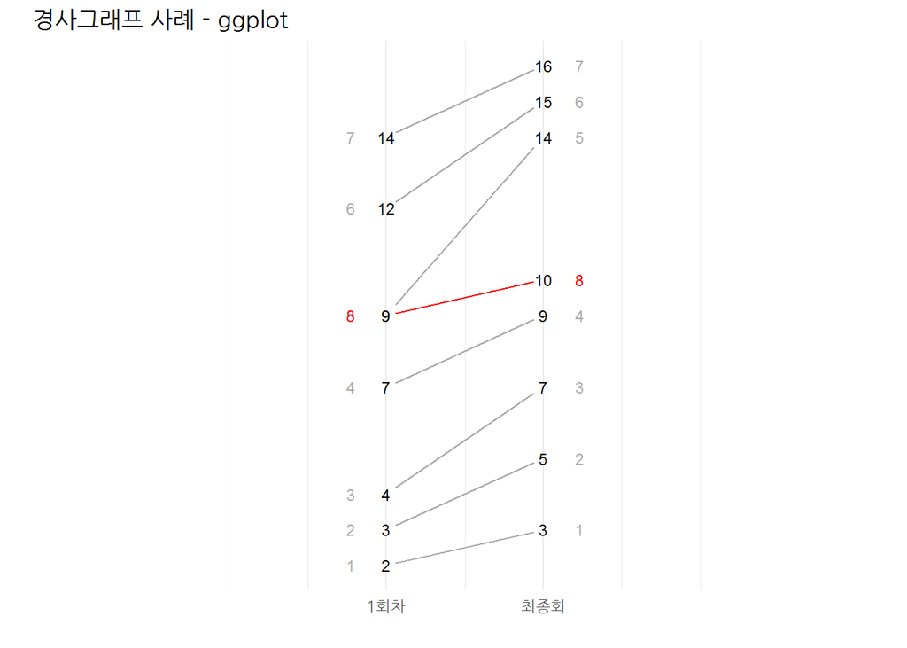

```r
ratings_dumbbell_df %>%
  spread(episode, viewers_7day) %>%
  as.data.frame() %>%
  column_to_rownames(var="series") %>%
  ggslopegraph(offset.x = 0.06, yrev = FALSE,
               col.lines = series_cols, col.lab = series_cols,
               main="경사그래프 사례 - ggplot") +
     theme_minimal(base_family = "NanumGothic")
```

## 4.7 시계열 데이터 비교

거시경제 등 시계열을 많이 다루는 분야에서 관심갖는 변수 2개이상을 시간의 흐름에 따라 비교하여 시각화하는 경우가 많고 다음과 같은 시각화 방법으로 R코드를 작성한다.

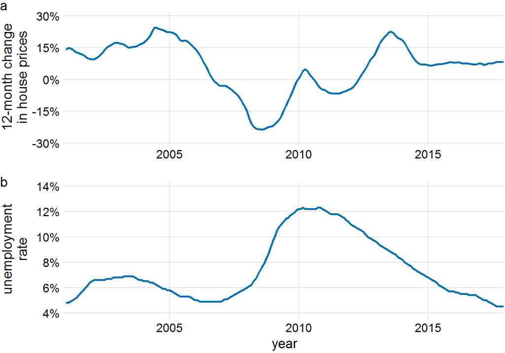

```r
# 데이터셋 준비

CA_house_prices <-
  filter(house_prices, state == "California", year(date) > 2000) %>%
  mutate(
    label = ifelse(
      date %in% c(ymd("2005-01-01"), ymd("2007-07-01"),
                  ymd("2010-01-01"), ymd("2012-07-01"), ymd("2015-01-01")),
      format(date, "%b %Y"), ""),
    nudge_x = case_when(
      label == "Jan 2005" ~ -0.003,
      TRUE ~ 0.003
    ),
    nudge_y = case_when(
      label == "Jan 2005" ~ 0.01,
      label %in% c("Jul 2007", "Jul 2012") ~ 0.01,
      TRUE ~ -0.01
    ),
    hjust = case_when(
      label == "Jan 2005" ~ 1,
      TRUE ~ 0
    )
  )

p1 <- ggplot(CA_house_prices, aes(date, house_price_perc)) +
  geom_line(size = 1, color = "#0072b2") +
  scale_y_continuous(
    limits = c(-0.3, .32), expand = c(0, 0),
    breaks = c(-.3, -.15, 0, .15, .3),
    name = "12-month change\nin house prices", labels = scales::percent_format(accuracy = 1)
  ) +
  scale_x_date(name = "", expand = c(0, 0)) +
  coord_cartesian(clip = "off") +
  theme_dviz_grid() +
  theme(
    axis.line = element_blank(),
    plot.margin = margin(12, 1.5, 0, 1.5)
  )
p2 <- ggplot(CA_house_prices, aes(date, unemploy_perc/100)) +
  geom_line(size = 1, color = "#0072b2") +
  scale_y_continuous(
    limits = c(0.037, 0.143),
    name = "unemployment\nrate", labels = scales::percent_format(accuracy = 1),
    expand = c(0, 0)
  ) +
  scale_x_date(name = "year", expand = c(0, 0)) +
  theme_dviz_grid() +
  theme(
    axis.line = element_blank(),
    plot.margin = margin(6, 1.5, 3, 1.5)
  )

plot_grid(p1, p2, align = 'v', ncol = 1, labels = "auto")
```

# 5 불확실성 시각화

## 5.1 들어가며

`ggplot` 팩키지에 `geom_pointrange()`가 기본디폴트로 설정되어 있는데 다른 요약 `aesthethics`에는 다양한 함수가 제공되고 있다.

- `geom_errorbar()`
- `geom_errorbar()`
- `geom_pointrange()`
- `geom_linerange()`
- `geom_crossbar()`

상기 `geom_*`와 대응하여 `Hmisc` 팩키지에 요약 통계량 함수(summary function)이 `stat_summary()` 함수로 포팅되어 `ggplot`에 녹여져있다. 공통적으로 `y`, `ymax`, `ymin`값을 반환시킨다.

- `mean_cl_normal()`
- `mean_sdl()`
- `mean_cl_boot()`
- `median_hilow()`

먼저 데이터를 준비하자. - 표준정규분포 - `n` - 오른쪽으로 치우친 분포 - `s` (Johnson distribution with skewness 2.2 and kurtosis 13) - 급첨분포(leptikurtic distribution) - `k` (Johnson distribution with skewness 0 and kurtosis 30) - 이봉분포(bimodal distribution) - `mm` (평균 -0.95, 0.95 와 표준편차 0.31)

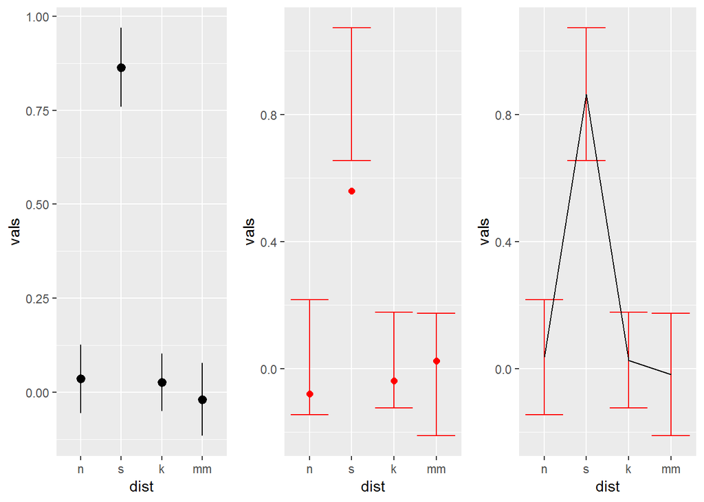

```r
# 데이터 -----
library(SuppDists) # install.packages("SuppDists")

findParams <- function(mu, sigma, skew, kurt) {
  value <- .C("JohnsonMomentFitR", as.double(mu), as.double(sigma),
    as.double(skew), as.double(kurt - 3), gamma = double(1),
    delta = double(1), xi = double(1), lambda = double(1),
    type = integer(1), PACKAGE = "SuppDists")
   list(gamma = value$gamma, delta = value$delta,
    xi = value$xi, lambda = value$lambda,
    type = c("SN", "SL", "SU", "SB")[value$type])
}
n <- rnorm(100)
s <- rJohnson(100, findParams(0, 1, 2.2, 13))
k <- rJohnson(100, findParams(0, 1, 0, 30))
mm <- rnorm(100, rep(c(-1, 1), each = 50) * sqrt(0.9), sqrt(0.1))

four_df <- data.frame(
  dist = factor(rep(c("n", "s", "k", "mm"), each = 100), c("n", "s", "k", "mm")),
  vals = c(n, s, k, mm))

library(Hmisc)

mean_se_g <- ggplot(four_df, aes(x = dist, y = vals, group=1)) +
  stat_summary(fun.data = "mean_se")

errorbar_g <- ggplot(four_df, aes(x = dist, y = vals)) +
    stat_summary(fun.y = "median", colour = "red", size = 2, geom = "point") +
  stat_summary(fun.data = "mean_cl_normal",
               geom ="errorbar",
               color="red")

group_errorbar_g <- ggplot(four_df, aes(x = dist, y = vals, group=1)) +
  stat_summary(fun.data = "mean_cl_normal",
               geom ="errorbar",
               color="red") +
  stat_summary(fun.y = mean, geom = "line")

cowplot::plot_grid(mean_se_g, errorbar_g, group_errorbar_g, ncol=3)
```

## 5.2 모평균 추정 시각화

모집단에서 나온 아래 관측점으로 표현하고 이를 평균낸 “표본 평균”을 오렌지 수직막대로 “표본 표준편차”도 함께 시각화하여 도식화시킬 수 있다.

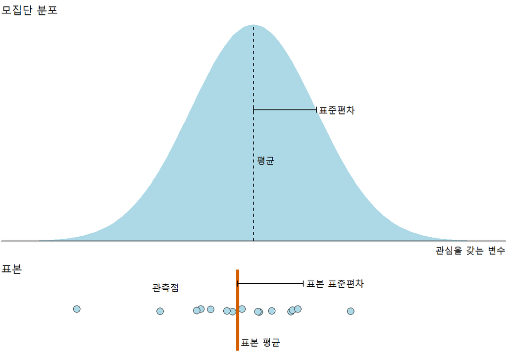

```r
set.seed(452061)

empty_theme <- theme_dviz_open(12, rel_small = 1, rel_large = 1) +
  theme(
    axis.line = element_blank(),
    axis.text = element_blank(),
    axis.ticks = element_blank(),
    axis.ticks.length = grid::unit(0, "pt")
  )

x <- c(seq(-4, 4, length.out = 200))
df_norm <- data.frame(
  x,
  y = dnorm(x)
)

sd_x <- c(-1, 1)
sd_y <- dnorm(sd_x)

df_annot <- data.frame(
  x = c(0.05, sd_x[2] + 0.04, -Inf),
  y = c(dnorm(0) * 0.4, sd_y[2] * 1.01, Inf), #sd_y[1] * 1.1
  hjust = c(0, 0, 0),
  vjust = c(1, 0.5, 1),
  label = c("평균", "표준편차", "모집단 분포")
)


p1 <- df_norm %>%
  ggplot(aes(x, y)) +
    geom_area(fill = "lightblue") +
    geom_segment( # 표준편차
      data = data.frame(x = 1), x = 0, xend = sd_x[2], y = sd_y[1], yend = sd_y[2],
      arrow = arrow(angle = 90, length = grid::unit(3, "pt"), ends = "both", type = "closed"),
      inherit.aes = FALSE
    ) +
    geom_segment( # 모평균 수직선
      data = data.frame(x = 1), x = 0, xend = 0, y = 0, yend = dnorm(0),
      linetype = 2,
      inherit.aes = FALSE
    ) +
    geom_text(data = df_annot,
      aes(x, y, label = label, hjust = hjust, vjust = vjust),
      family = dviz_font_family,
      size = c(12, 12, 14)/.pt
    ) +
    scale_x_continuous(
      limits = c(-4, 4), expand = c(0, 0),
      breaks = 0, # workaround to fix missing axis line
      name = "관심을 갖는 변수"
    ) +
    scale_y_continuous(breaks = NULL, name = NULL, expand = expand_scale(mult = c(0, 0.1))) +
    empty_theme +
    theme(axis.line.x = element_line(), axis.title.x = element_text(hjust = 1))


df_sample <- data.frame(x = rnorm(15),  y = 0)

df_annot2 <- data.frame(
  x = c(mean(df_sample$x) + 0.05, sort(df_sample$x)[2],
        mean(df_sample$x) + sd(df_sample$x) + 0.05, -Inf),
  y = c(-0.15, 0.12, .13 + 0.01, Inf),
  hjust = c(0, 0.3, 0, 0),
  vjust = c(0.5, 0.5, 0.5, 1),
  label = c("표본 평균", "관측점", "표본 표준편차", "표본")
)


p2 <- df_sample %>%
  ggplot(aes(x, y)) +
    geom_point(
      size = 3, fill = "lightblue", shape = 21, stroke = 0.5,
      position = position_jitter(width = 0, height = 0.01, seed = 127)) +
    geom_segment( # 표본평균을 표식하는 수직막대
      data = data.frame(x = 1),
      aes(x = mean(df_sample$x), xend = mean(df_sample$x), y = -.2, yend = .2),
      size = 1.5,
      color = "#D55E00",
      inherit.aes = FALSE) +
    geom_segment( # horizontal bar representing sd
      data = data.frame(x = 1),
      x = mean(df_sample$x), xend = mean(df_sample$x) + sd(df_sample$x), y = .13, yend = .13,
      arrow = arrow(angle = 90, length = grid::unit(3, "pt"), ends = "both", type = "closed"),
      inherit.aes = FALSE) +
    geom_text(
      data = df_annot2,
      aes(x, y, label = label, hjust = hjust, vjust = vjust),
      family = dviz_font_family,
      size = c(12, 12, 12, 14)/.pt) +
    scale_x_continuous(limits = c(-4, 4), expand = c(0, 0), breaks = NULL, name = NULL) +
    scale_y_continuous(expand = c(0.1, 0), breaks = NULL, name = NULL) +
    empty_theme

plot_grid(p1, p2, ncol = 1, rel_heights = c(1, .4, 1), align = 'v')
```

## 5.3 신뢰구간

`cacao` 데이터프레임에서 캐나다만 필터링하여 데이터프레임을 만든 후에 신뢰구간별 통계량을 계산한 후에 `ggplot`으로 시각화한다.

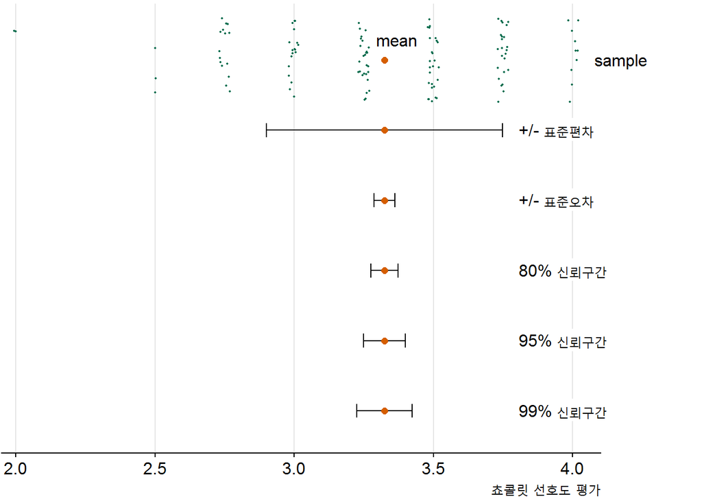

```r
library(emmeans)
point_color <- darken("#009E73", .3)

cacao_single <- cacao %>%
  filter(location == "Canada")

cacao_fit <- lm(rating ~ 1, data = cacao_single)

CI_df <- data.frame(type = c(0.8, 0.95, 0.99)) %>%
  mutate(df = map(type, ~broom::tidy(emmeans(cacao_fit, ~ 1, options = list(level = .x))))) %>%
  unnest() %>%
  select(type, estimate, std.error, conf.low, conf.high) %>%
  mutate(type = paste0(signif(100*type, 2), "% 신뢰구간"))

CI_df <- rbind(CI_df,
  data.frame(
    type = "standard error",
    estimate = CI_df$estimate[1],
    std.error = CI_df$std.error[1],
    conf.low = CI_df$estimate[1] - CI_df$std.error[1],
    conf.high = CI_df$estimate[1] + CI_df$std.error[1]),
  data.frame(
    type = "standard deviation",
    estimate = mean(cacao_single$rating),
    std.error = CI_df$std.error[1],
    conf.low = mean(cacao_single$rating) - sd(cacao_single$rating),
    conf.high = mean(cacao_single$rating) + sd(cacao_single$rating)),
  data.frame(
    type = "sample", estimate = mean(cacao_single$rating), std.error = NA,
    conf.low = NA, conf.high = max(cacao_single$rating))
) %>%
  mutate(
    type = fct_relevel(factor(type), "sample", "standard deviation", "standard error"),
    label = case_when(
      type == "sample" ~ NA_character_,
      type == "standard deviation" ~ "+/- 표준편차",
      type == "standard error" ~ "+/- 표준오차",
      TRUE ~ as.character(type) #paste0("mean +/- ", type)
    )
  )

label_x <- filter(CI_df, type == "standard deviation")$conf.high + 0.04

ggplot(CI_df, aes(estimate, type)) +
  geom_point(
    data = cacao_single, aes(rating, "sample"),
    position = position_jitter(height = 0.6, width = 0.02, seed = 7843),
    color = point_color,
    size = 0.3) +
  geom_errorbarh(aes(xmin = conf.low, xmax = conf.high), height = 0.2, na.rm = TRUE) +
  geom_point(size = 2, color = "#D55E00") +
  geom_label(
    aes(label_x, label = label), hjust = 0, nudge_y = 0.01, na.rm = TRUE,
    family = dviz_font_family,
    size = 12/.pt,
    label.size = 0) +
  geom_label(
    data = filter(CI_df, type == "sample"),
    aes(conf.high + 0.06, label = type), hjust = 0, nudge_y = 0.01,
        family = dviz_font_family,
        size = 12/.pt,
        label.size = 0) +
  geom_text(
    data = filter(CI_df, type == "sample"),
    aes(estimate, label = "mean"), hjust = 0.2, vjust = 0, nudge_y = 0.2,
    family = dviz_font_family,
    size = 12/.pt) +
  scale_x_continuous(
    limits = c(1.95, 4.1),
    expand = c(0, 0),
    name = "쵸콜릿 선호도 평가" ) +
  scale_y_discrete(
    name = NULL,
    limits = rev(levels(CI_df$type)),
    expand = expand_scale(add = c(0.6, 0.8)),
    breaks = NULL) +
  coord_cartesian(clip = "off") +
  theme_dviz_vgrid(12, rel_small = 1) +
  theme(
    plot.margin = margin(3, 73, 3, 1.5),
    axis.line.x = element_line(),
    axis.ticks.x = element_line(color = "black"),
    axis.title.x = element_text(hjust = 1)
  )
```

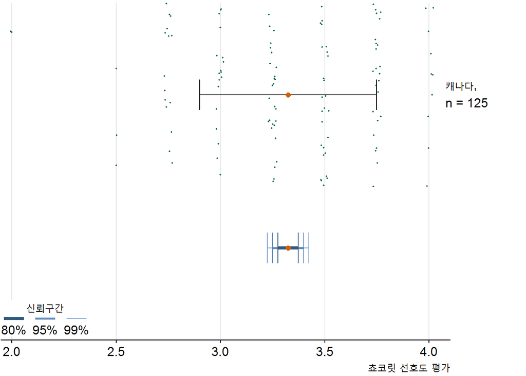

```r
cacao_CA <- filter(cacao, location == "Canada")

fit_CA <- lm(rating ~ 1, data = cacao_CA)

CI_CA_df <- data.frame(level = c(0.99, 0.95, 0.8)) %>%
  mutate(df = map(level, ~broom::tidy(emmeans(fit_CA, ~ 1, options = list(level = .x))))) %>%
  unnest() %>%
  select(level, estimate, conf.low, conf.high) %>%
  mutate(
    level = paste0(signif(100*level, 2), "%"),
    type = "CI",
    location = "Canada"
  )

CI_CA_sd_df <- data.frame(
    level = NA,
    estimate = mean(cacao_CA$rating),
    conf.low = mean(cacao_CA$rating) - sd(cacao_CA$rating),
    conf.high = mean(cacao_CA$rating) + sd(cacao_CA$rating),
    type = "original data",
    location = "Canada")

ggplot(rbind(CI_CA_df, CI_CA_sd_df), aes(estimate, interaction(location, type))) +
  geom_point(
    data = cacao_CA, # draw two separate layers to get jittering right relative to previous figure
    aes(rating, interaction(location, "original data")),
    position = position_jitter(height = 0.6, width = 0.02, seed = 7843),
    color = point_color,
    size = 0.3) +
  geom_errorbarh(
    data = CI_CA_sd_df,
    aes(y = interaction(location, "original data"), xmin = conf.low, xmax = conf.high),
    height = 0.2) +
  geom_errorbarh(
    data = CI_CA_df,
    aes(y = interaction(location, "CI"), xmin = conf.low, xmax = conf.high, color = level, size = level),
    height = 0) +
  geom_errorbarh(
    data = CI_CA_df,
    aes(y = interaction(location, "CI"), xmin = conf.low, xmax = conf.high, color = level),
    height = 0.2) +
  geom_point(size = 2, color = "#D55E00") +
  geom_label(
    data = data.frame(
      estimate = 4.06,
      location = c("Canada"),
      type = "original data",
      label = c(
        paste0("캐나다,\nn = ", nrow(cacao_CA))
      )
    ),
    aes(label = label), hjust = 0, vjust = 0.5, nudge_y = 0.01,
    family = dviz_font_family,
    size = 12/.pt,
    label.size = 0
  ) +
  scale_x_continuous(
    limits = c(1.95, 4.1),
    expand = c(0, 0),
    name = "쵸코릿 선호도 평가"
  ) +
  scale_y_discrete(
    name = NULL,
    limits = rev(c("Canada.original data", "Canada.CI")),
    # expand = expand_scale(add = c(1, 0.8)),
    breaks = NULL
  ) +
  scale_fill_manual(
    aesthetics = c("color", "fill"),
    name = "신뢰구간",
    values = c(
     `80%` = desaturate(darken("#0072B2", .2), .3),
     `95%` = desaturate(lighten("#0072B2", .2), .3),
     `99%` = desaturate(lighten("#0072B2", .4), .3)
    ),
    guide = guide_legend(
      direction = "horizontal",
      title.position = "top",
      label.position = "bottom"
    )
  ) +
  scale_size_manual(
    name = "신뢰구간",
    values = c(
     `80%` = 1.5,
     `95%` = 1,
     `99%` = 0.5
    ),
    guide = guide_legend(
      direction = "horizontal",
      title.position = "top",
      label.position = "bottom"
    )
  ) +
  coord_cartesian(clip = "off") +
  theme_dviz_vgrid(12, rel_small = 1) +
  theme(
    plot.margin = margin(3, 73, 3, 1.5),
    axis.line.x = element_line(),
    axis.ticks.x = element_line(color = "black"),
    axis.title.x = element_text(hjust = 1),
    legend.position = c(0, 0.01),
    legend.justification = c(0, 0),
    legend.key.height = grid::unit(6, "pt"),
    legend.key.width = grid::unit(24, "pt"),
    legend.spacing.x = grid::unit(6, "pt"),
    legend.spacing.y = grid::unit(3, "pt"),
    legend.box.background = element_rect(fill = "white", color = NA),
    legend.box.spacing = grid::unit(0, "pt"),
    legend.title.align = 0.5
  )
```

[^1]: [Claus O. Wilke, “Fundamentals of Data Visualization”, O’Reilly Media, Inc.](https://serialmentor.com/dataviz/)
[^2]: [Peter Prevos (February 24, 2019), “Strategic Data Science: Creating Value With Data Big and Small”, The Lucid Manager](https://lucidmanager.org/strategic-data-science/)
[^3]: [BBC - `bbplot`](https://github.com/bbc/bbplot)
[^4]: [“BBC Visual and Data Journalism cookbook for R graphics”](https://bbc.github.io/rcookbook/)
[^5]: [Hiroaki Yutani (June 3, 2018), “Anatomy of gghighlight”](https://yutani.rbind.io/post/2018-06-03-anatomy-of-gghighlight/)
[^6]: [BLOGR (2016), “Plotting background data for groups with ggplot2”](https://drsimonj.svbtle.com/plotting-background-data-for-groups-with-ggplot2)
[^7]: [CS631: Principles & Practice of Data Visualization (Spring 2018)](https://apreshill.github.io/data-vis-labs-2018/04-challenge.html)
[^8]: [UC Business Analytics R Programming Guide , “Lollipop Charts”](https://uc-r.github.io/lollipop)
[^9]: [Chuck Powell (2018-06-22), “Visualizing Data in R - Creating Slopegraphs with R”](https://datascienceplus.com/creating-slopegraphs-with-r/)